# Assignment 1

Write the code to implement the data simulation demonstrated in the video ["Statistics Without the Agonizing Pain"](https://www.youtube.com/watch?v=5Dnw46eC-0o&feature=emb_title). Calculate the probability of obtaining the experiment outcome.

To answer this question we need to find probability that experiment outcome (4.4 difference between means for number of mosquitos in beer subgroup and water subgroup) is just by chance. But to find probability we need many experiments (or trials), since probability is defined as ratio of number of plausible outcomes to the number of trials.

We have to run many experiments with X volunteers who drink beer and Y volunteers who drink water, while we have only one experiment with 25 volunteers (beer) and 18 volunteers (water). This problem can be solved by simulation - we shuffle the dataset many times (say 10,000 iterations) and each time split the data sets into 2 subgroups (25 for beer and 18 for water). Next compute the mean for ech subgroup and the mean difference. This way we will simulate 10,000 experiments and we should have 10,000 values for the mean difference.

The next step is to find probability of obtaining the experiment outcome (4.4):

this can be computed as the number of times 4.4 appears in 10,000 simulated experiments divided by the total number of experiments (10,000); or find the number of simulated experiments with outcome 4.4 or greater and divide this by the total number of experiments (10,000) - this is proper way to define probability, it will be discussed later in the course.

```python
# Importing libraries
import numpy as np
import pandas as pd
import matplotlib.pyplot as plt
import seaborn as sns
```

```python
# Read the dataset
df = pd.read_csv("mosquitos_data.csv")
df.head()
```

|  | Response | Treatment |
| --- | --- | --- |
| 0 | 27 | Beer |
| 1 | 20 | Beer |
| 2 | 21 | Beer |
| 3 | 26 | Beer |
| 4 | 27 | Beer |

## Q.1. Create side-by-side boxplots for the number of mosquitoes in each group (beer vs water)

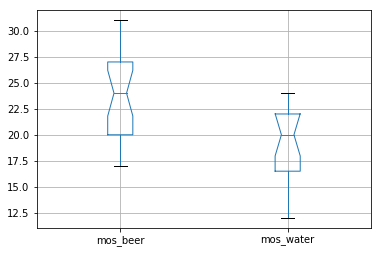

```python
# Boxplot using matplotlib
df['mos_beer'] = df[df['Treatment'] == 'Beer']['Response']
df['mos_water'] = df[df['Treatment'] == 'Water']['Response']
df_1 = pd.DataFrame(data= df, columns = ['mos_beer','mos_water'])
df_1.boxplot(notch = True)
```

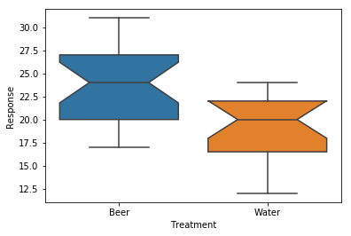

```python
# Boxplot using seaborn
sns.boxplot(x= 'Treatment', y= 'Response', data= df, notch=True)
```

## Q.2 What does the graph reveal about the data for both groups? Is there an association between beer consumption and attractiveness to mosquitoes?

Ans: Box plots (also known as box and whisker plots) are a type of chart often used in explanatory data analysis to visually show the distribution of numerical data and skewness through displaying the data quartiles (or percentiles) and averages. They have the advantage of taking up less space in comparison to a histogram or density plot, which is useful when comparing distributions between many groups or datasets.

[figure not shown]

A boxplot can tell:

1. The outliers and their values
2. Identify if the data is symmetrical
3. Determine how tightly the data is grouped
4. See if the data is skewed

**There is absence of outliers in the given dataset**

**For the beer drinking group, median is in the middle of the box, and the whiskers are about the same on both sides of the box, so the distribution is nearly symmetric. On the other hand, median for water drinking group is closer to the top of the box , and the whisker is shorter on the upper end of the box, therefore distribution is negatively skewed (skewed left).**

**The box for the beer group is longer which signifies the data is more dispersed in that case as compared to water group.**

**From graph, we can see that the mean(23.6) and median(24) values of beer drinking group is greater than the water drinking group(mean=19.222222, median= 20) which indicates there is association between beer consumption and attractiveness to mosquitoes.**

```python
mean = np.mean(df['mos_beer']) - np.mean(df['mos_water'])
mean
```

```
4.37777777777778
```

```python
df['mos_beer'].describe()
```

```
count    25.000000
mean     23.600000
std       4.133199
min      17.000000
25%      20.000000
50%      24.000000
75%      27.000000
max      31.000000
Name: mos_beer, dtype: float64
```

```python
df['mos_water'].describe()
```

```
count    18.000000
mean     19.222222
std       3.671120
min      12.000000
25%      16.500000
50%      20.000000
75%      22.000000
max      24.000000
Name: mos_water, dtype: float64
```

## Q.3 Calculate basic statistics measures for each group: the mean, median, standard deviation and explain the numbers.

Ans: From the above two cells we can check the basic statistics for both groups:

| Statistics | Beer | Water |
| --- | --- | --- |
| mean | 23.600000 | 19.222222 |
| std | 4.133199 | 3.671120 |
| median | 24.000000 | 20.000000 |

The mean and the median are both measures of central tendency; they give an indication of the average value of a distribution of figures. The sample mean is the average and is computed as the sum of all the observed outcomes from the sample divided by the total number of events. One problem with using the mean, is that it often does not depict the typical outcome. If there is one outcome that is very far from the rest of the data, then the mean will be strongly affected by this outcome. Such an outcome is called an outlier. An alternative measure is the median. The median is the middle score. If we have an even number of events we take the average of the two middles. The median is better for describing the typical value.

**As we can see there is not much difference between mean and median values it indicates the absence of outliers in the given dataset.**

The mean and median do a nice job in telling where the center of the data set is, but often we are interested in more. For example, a pharmaceutical engineer develops a new drug that regulates iron in the blood. Suppose she finds out that the average sugar content after taking the medication is the optimal level. This does not mean that the drug is effective. There is a possibility that half of the patients have dangerously low sugar content while the other half have dangerously high content. Instead of the drug being an effective regulator, it is a deadly poison. What the pharmacist needs is a measure of how far the data is spread apart. This is what standard deviation and Interquartile range(IQR) do.

## 4. Write the code to implement the data simulation demonstrated in the above mentioned video. Calculate the probability of obtaining the experiment outcome.

```
1 4.760000000000002
2 4.664444444444442
3 5.428888888888888
4 4.568888888888889
5 4.473333333333333
6 4.664444444444442
7 4.760000000000002
8 4.568888888888889
9 5.046666666666667
10 5.333333333333332
11 4.568888888888889
12 4.473333333333333
13 4.760000000000002
14 4.473333333333333
15 4.568888888888889
16 4.855555555555558
17 4.568888888888889
18 4.951111111111111
19 4.568888888888889
20 4.568888888888889
21 4.760000000000002
22 4.568888888888889
23 4.855555555555558
24 4.473333333333333
25 4.568888888888889
26 4.473333333333333
```

[output not shown]

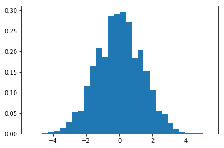

```python
# Code to implement the data simulation demonstrated in video
array = df['Response'].to_numpy()
N=50000
result = []
k=0
for iter in range(N):
    arr1=array
    arr2=np.random.permutation(arr1)
    mean = np.mean(arr2[:25]) - np.mean(arr2[25:])
    result.append(mean)
    if 4.4 <= mean:
        k=k+1
        print(k, mean)
plt.figure()
plt.hist(result, normed=True, bins=30)
# Show figure as desired.
plt.show()
```

```python
# Calculate the probability of obtaining the experiment outcome
print('P(mean>=4.4)=',k/N)
```

```
P(mean>=4.4)= 0.00052
```

**Submitted by: Manjeet Kaur**